# Prediction Assignment - Practical Machine Learning Coursera

Tez Osman

25 July 2016

### Introduction

Using devices such as Jawbone Up, Nike FuelBand, and Fitbit it is now possible to collect a large amount of data about personal activity relatively inexpensively. These type of devices are part of the quantified self movement – a group of enthusiasts who take measurements about themselves regularly to improve their health, to find patterns in their behavior, or because they are tech geeks. One thing that people regularly do is quantify how much of a particular activity they do, but they rarely quantify how well they do it. In this project, your goal will be to use data from accelerometers on the belt, forearm, arm, and dumbell of 6 participants. They were asked to perform barbell lifts correctly and incorrectly in 5 different ways. More information is available from the website here: http://groupware.les.inf.puc-rio.br/har (see the section on the Weight Lifting Exercise Dataset).

## Loading in the dataset

Firstly laod all of the respective libraries

```r
library(caret)
```

```r
library(rpart)
library(rpart.plot)
library(RColorBrewer)
library(rattle)
library(randomForest)
```

Download and load data

```r
download.file(url = "https://d396qusza40orc.cloudfront.net/predmachlearn/pml-training.csv",
              destfile = "./pml-training.csv", method = "curl")

dt_training <- read.csv("./pml-training.csv", na.strings=c("NA","#DIV/0!",""))

download.file(url = "https://d396qusza40orc.cloudfront.net/predmachlearn/pml-testing.csv",
              destfile = "./pml-testing.csv", method = "curl")

dt_testing <- read.csv("./pml-testing.csv", na.strings=c("NA","#DIV/0!",""))
```

## Cleaning up the data

Firstly we will clean up the NA columns and remove the features that are not in the testing data. The fautures that do contain NAs are the variance, mean and standard deviation. Since the dataset has no time dependance, these values can be disregarded. The first 7 features will also be disregarded as they are related to the time series and are not numeric

```r
features <- names(dt_testing[,colSums(is.na(dt_testing)) == 0])[8:59]
dt_training <- dt_training[,c(features,"classe")]
dt_testing <- dt_testing[,c(features,"problem_id")]
dim(dt_training); dim(dt_testing);
```

```
## [1] 19622    53
```

```
## [1] 20 53
```

## Partition the Dataset

In this step we will split our data into a training data set - 60% of the total cases and a testing data set of 40%. THis will allow us to work our the sample error of our predictotor

```r
set.seed(12345)

inTrain <- createDataPartition(dt_training$classe, p=0.6, list=FALSE)
training <- dt_training[inTrain,]
testing <- dt_training[-inTrain,]

dim(training); dim(testing);
```

```
## [1] 11776    53
```

```
## [1] 7846   53
```

## Building the decision tree model.

Lets build out the decision tree. Anything around the 80% would be good enough.

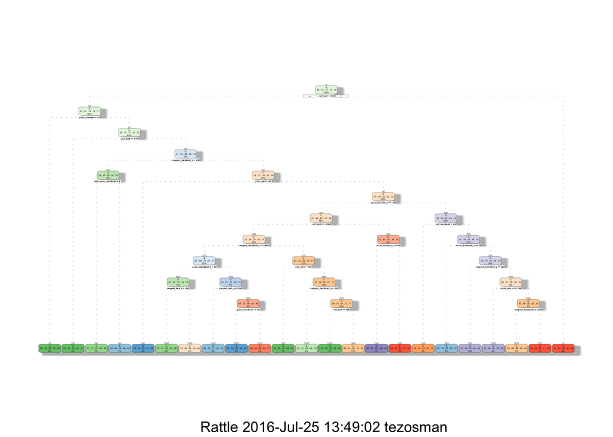

```r
modFitDT <- rpart(classe ~ ., data = training, method="class")
fancyRpartPlot(modFitDT)
```

## Predicting with the decision tree model.

```r
set.seed(12345)

prediction <- predict(modFitDT, testing, type = "class")
table(prediction, testing$classe)
```

```
##
## prediction    A    B    C    D    E
##          A 1879  260   30   69   66
##          B   56  759   88   34   54
##          C  105  340 1226  354  234
##          D  155  132   23  807   57
##          E   37   27    1   22 1031
```

## Building the random forest model

Using the random forest, the out of sample error should be relatively small. As the error will be estimated using the 40% testing sample, we should expect to see the error estimate at <3%

```r
set.seed(12345)
modFitRF <- randomForest(classe ~ ., data = training, ntree = 1000)
```

## Predicting with the Forest Model

```r
prediction <- predict(modFitRF, testing, type = "class")
table(prediction, testing$classe)
```

```
##
## prediction    A    B    C    D    E
##          A 2230    9    0    0    0
##          B    2 1504    6    0    0
##          C    0    5 1362   17    2
##          D    0    0    0 1267    5
##          E    0    0    0    2 1435
```

## Predicting on the testing data.

Decision Tree Prediction code.

```r
predictionDT <- predict(modFitDT, dt_testing, type = "class")
predictionDT
```

```
##  1  2  3  4  5  6  7  8  9 10 11 12 13 14 15 16 17 18 19 20
##  C  A  C  A  A  E  D  D  A  A  A  C  A  A  C  E  A  D  C  B
## Levels: A B C D E
```

## Random Forest Prediction.

```r
predictionRF <- predict(modFitRF, dt_testing, type = "class")
predictionRF
```

```
##  1  2  3  4  5  6  7  8  9 10 11 12 13 14 15 16 17 18 19 20
##  B  A  B  A  A  E  D  B  A  A  B  C  B  A  E  E  A  B  B  B
## Levels: A B C D E
```

## Submission File

We can see from our results that the Random forest model is accurate. At around 99%. As a result of this we could expect nearly all of the sumbitted test cases to be correct.

Prapare the submission.

```r
pml_write_files = function(x){
  n = length(x)
  for(i in 1:n){
    filename = paste0("problem_id_",i,".txt")
    write.table(x[i],file=filename,quote=FALSE,row.names=FALSE,col.names=FALSE)
  }
}
pml_write_files(predictionRF)
```